# Joining tables with `dplyr`

Author

Casey Schine adapted from Emily Malcolm-White

# Housekeeping

- Switching back to skills for 2 weeks to learn some more advanced skills that you will need for your Final Project

# `nycflights23` dataset

```r
#LOAD PACKAGES
library(tidyverse)

#LOAD DATA
library(nycflights23)
data("flights")
```

`nycflights23` contains information about all 435352 flights departing NYC in 2023.

# Join dataframes

## Matching key variable names

Some airline names might be easy to guess (ie. “UA” is United Airlines), but what airlines have the code “VX”, “HA”, and “B6”? Data on airline codes is provided in a dataset called `airlines`.

```r
data("airlines")
```

We want to have all this information in one data frame instead of two separate data frames.

The variable `carrier` in `flights` match the variable `carrier` in the `airlines` dataset – this is our *key variable*. In this case, they have the same name, but this doesn’t necessarily have to be true.

```r
# look at carrier variable in airlines data
# open data in viewer

# look at carrier variable in flights data
# Data set is too long to just click on it and get a good look, so what can we do here?

# use distinct() to look at all of the carriers

flights |>
  distinct(carrier)
```

```
# A tibble: 14 × 1
   carrier
   <chr>
 1 UA
 2 DL
 3 B6
 4 AA
 5 NK
 6 WN
 7 AS
 8 YX
 9 9E
10 HA
11 G4
12 MQ
13 OO
14 F9
```

**Different Types of Joins**

There are several different kinds of joins. Which one you choose will depend on what you are trying to accomplish.

```r
# use "key" variable to join the two data sets
# ?join to look at the help documentation
# what variable can we use to join these two datasets?

#carrier

# new syntax, by=join_by(column_name), column_name does not go in quotes

flights_joined <- flights |>
  left_join(airlines, by=join_by(carrier))


# check join using filter(is.na()) to check for the introduction of NAs by a bad join

flights_joined |>
  filter(is.na(name))
```

```
# A tibble: 0 × 20
# ℹ 20 variables: year <int>, month <int>, day <int>, dep_time <int>,
#   sched_dep_time <int>, dep_delay <dbl>, arr_time <int>,
#   sched_arr_time <int>, arr_delay <dbl>, carrier <chr>, flight <int>,
#   tailnum <chr>, origin <chr>, dest <chr>, air_time <dbl>, distance <dbl>,
#   hour <dbl>, minute <dbl>, time_hour <dttm>, name <chr>
```

## Different key variable names

```r
data("airports")
```

In `airports` the airport code is in `faa`, whereas in `flights` the airport codes are in `origin` and `dest`.

```r
# look at airports and flights data to find where airport variables are stored

# join airport to flights data
# reminder: by=join_by(dest==faa)
# rename new variable to destination name using rename(new_name=old_name)

flights_joined_airport <- flights_joined |>
  left_join(airports, by=join_by(dest==faa)) |>
  rename(carrier_name=name.x, destination_airport=name.y)


# check the join
# use filter(is.na()) to check for the introduction of NAs by a bad join

flights_joined_airport |>
  filter(is.na(destination_airport))
```

```
# A tibble: 0 × 27
# ℹ 27 variables: year <int>, month <int>, day <int>, dep_time <int>,
#   sched_dep_time <int>, dep_delay <dbl>, arr_time <int>,
#   sched_arr_time <int>, arr_delay <dbl>, carrier <chr>, flight <int>,
#   tailnum <chr>, origin <chr>, dest <chr>, air_time <dbl>, distance <dbl>,
#   hour <dbl>, minute <dbl>, time_hour <dttm>, carrier_name <chr>,
#   destination_airport <chr>, lat <dbl>, lon <dbl>, alt <dbl>, tz <dbl>,
#   dst <chr>, tzone <chr>
```

### In Groups

In groups, construct the chain of pipe operators |> that computes the number of flights from NYC to each destination, but also includes information about each destination airport. Start with the first part, compute the number of flights from NYC to each destination, and then do your join.

```r
# In groups!!!

dest_summary <- flights |>
  count(dest) |>
  left_join(airports, by=join_by(dest==faa))

dest_summary_summarize <- flights |>
  group_by(dest) |>
  summarize(count=n()) |>
  left_join(airports, by=join_by(dest==faa))
```

Now, make a kable table with the top 5 airports (the airports most flown to from NYC) with airport name in the first column, the airport code in the next column, and the number of flights to that airport from NYC in the third column.

```r
library(kableExtra)

# hint: slice() will not work with a grouped dataset, you need to ungroup() it first

dest_summary |>
  arrange(desc(n)) |>
  slice(1:5) |>
  select(`Airport Name`=name, airport_code=dest, count=n) |>
  kbl() |>
  kable_styling()
```

| Airport Name | airport_code | count |
| --- | --- | --- |
| General Edward Lawrence Logan International Airport | BOS | 19036 |
| Chicago O'Hare International Airport | ORD | 18200 |
| Orlando International Airport | MCO | 17756 |
| Hartsfield Jackson Atlanta International Airport | ATL | 17570 |
| Miami International Airport | MIA | 16076 |

## Multiple Key variables

In order to join the flights and weather data frames, we need more than one key variable: `year`, `month`, `day`, `hour`, and `origin`. This is because the combination of these 5 variables act to uniquely identify each observational unit in the weather data frame: hourly weather recordings at each of the 3 NYC airports.

```r
data("weather")
```

```r
# join weather data to flights using left_join()
# what variables do we need for a clean join?

# what is in weather data???

# what are the matching variables in flights that we need???
#time_hour
#origin

# join with left_join()

flights_weather_joined <- flights |>
  left_join(weather, by=join_by(time_hour, origin))

flights_weather_joined |>
  filter(is.na(precip))
```

```
# A tibble: 826 × 32
   year.x month.x day.x dep_time sched_dep_time dep_delay arr_time
    <int>   <int> <int>    <int>          <int>     <dbl>    <int>
 1   2023       5     2      551            550         1      847
 2   2023       5     2      553            555        -2      750
 3   2023       5     2      555            559        -4      750
 4   2023      12    31      107           2250       137      355
 5   2023      12    31      459            510       -11      744
 6   2023      12    31      459            501        -2      955
 7   2023      12    31      509            508         1      754
 8   2023      12    31      509            510        -1      744
 9   2023      12    31      510            510         0      748
10   2023      12    31      511            519        -8      758
# ℹ 816 more rows
# ℹ 25 more variables: sched_arr_time <int>, arr_delay <dbl>, carrier <chr>,
#   flight <int>, tailnum <chr>, origin <chr>, dest <chr>, air_time <dbl>,
#   distance <dbl>, hour.x <dbl>, minute <dbl>, time_hour <dttm>, year.y <int>,
#   month.y <int>, day.y <int>, hour.y <int>, temp <dbl>, dewp <dbl>,
#   humid <dbl>, wind_dir <dbl>, wind_speed <dbl>, wind_gust <dbl>,
#   precip <dbl>, pressure <dbl>, visib <dbl>
```

```r
flights_weather_joined <- flights |>
  left_join(weather, by=join_by(time_hour, origin, year, month, day, hour))

flights_weather_joined |>
  filter(is.na(precip))
```

```
# A tibble: 826 × 28
    year month   day dep_time sched_dep_time dep_delay arr_time sched_arr_time
   <int> <int> <int>    <int>          <int>     <dbl>    <int>          <int>
 1  2023     5     2      551            550         1      847            852
 2  2023     5     2      553            555        -2      750            754
 3  2023     5     2      555            559        -4      750            759
 4  2023    12    31      107           2250       137      355            203
 5  2023    12    31      459            510       -11      744            804
 6  2023    12    31      459            501        -2      955            942
 7  2023    12    31      509            508         1      754            823
 8  2023    12    31      509            510        -1      744            802
 9  2023    12    31      510            510         0      748            825
10  2023    12    31      511            519        -8      758            827
# ℹ 816 more rows
# ℹ 20 more variables: arr_delay <dbl>, carrier <chr>, flight <int>,
#   tailnum <chr>, origin <chr>, dest <chr>, air_time <dbl>, distance <dbl>,
#   hour <dbl>, minute <dbl>, time_hour <dttm>, temp <dbl>, dewp <dbl>,
#   humid <dbl>, wind_dir <dbl>, wind_speed <dbl>, wind_gust <dbl>,
#   precip <dbl>, pressure <dbl>, visib <dbl>
```

### In groups

In groups, join the `weather` data to the `flights` data with an `inner_join()`.

```r
flights_weather_inner_join <- flights |>
  inner_join(weather, by=join_by(time_hour, origin, year, month, day, hour))
```

```r
# We can use anti_join() to look specifically at the unmatched rows
# this will tell us which rows in flight do not have matching weather data

flights_weather_anti_join <- flights |>
  anti_join(weather, by=join_by(time_hour, origin, year, month, day, hour))

flights_weather_anti_join |>
  distinct(origin, year, month, day)
```

```
# A tibble: 4 × 4
  origin  year month   day
  <chr>  <int> <int> <int>
1 LGA     2023     5     2
2 LGA     2023    12    31
3 EWR     2023    12    31
4 JFK     2023    12    31
```

## Why is this useful?

Joins allow you to bring in additional data that you can then use in conjuction with your dataset of interest.

An example of how this can be useful is in altering your labels on a plot:

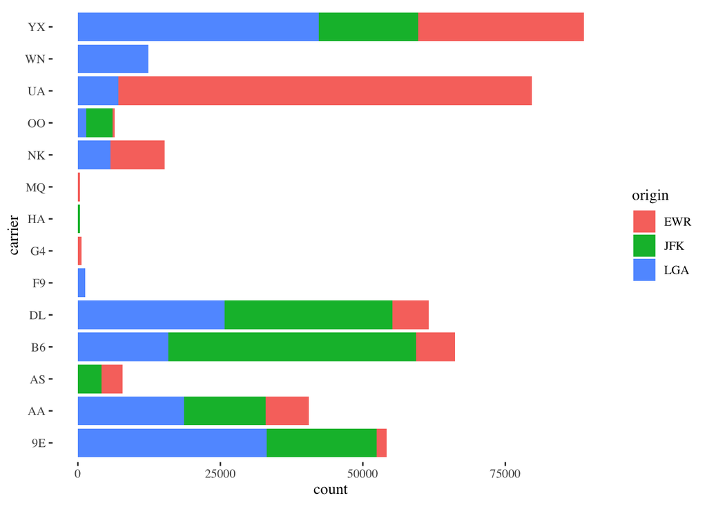

```r
library(ggthemes)
# make bar plot (using geom_bar) with y as carrier and fill as origin
# use original flights dataset

flights |>
  ggplot(aes(y=carrier, fill=origin)) +
  geom_bar() +
  theme_tufte()
```

### In groups

Now make the same figure as above, but use joining to replace the origin airport code with the origin airport name using the `aiports` dataset and the carrier code with the carrier name using the `airlines` dataset.

*Hint: if doing it all at once seems overwhelming do it one piece at a time and then put all of the pieces together. First, do the airports join. Then do the airlines join. And then put them together.*

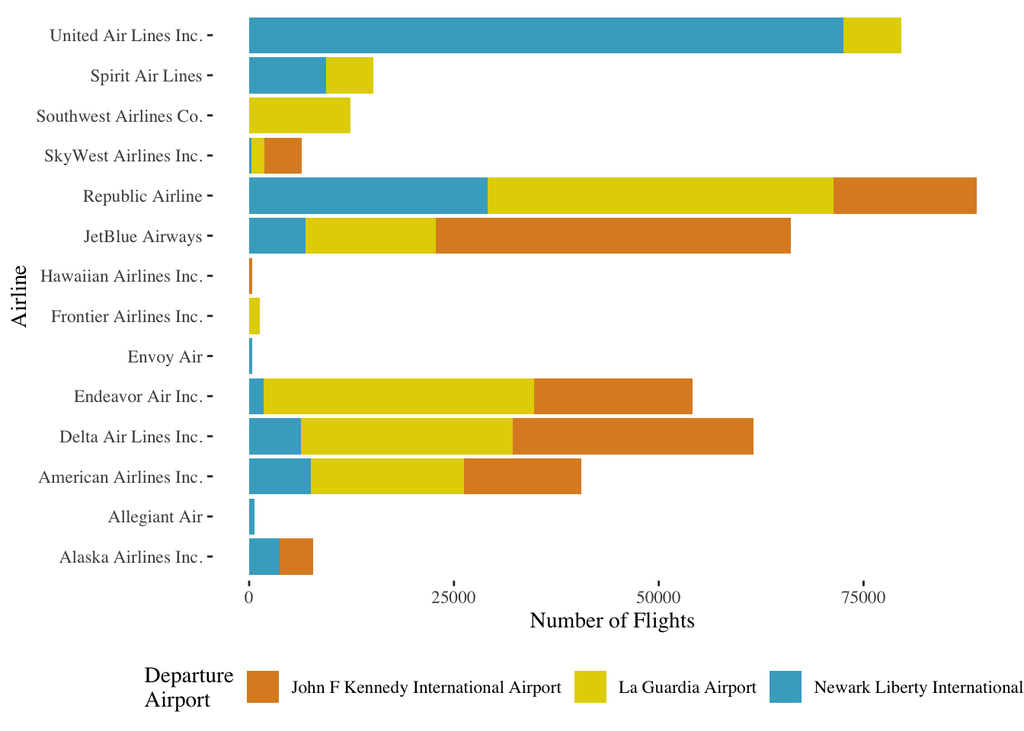

```r
library(wesanderson)
# now do the same thing but join the airports and airlines datasets to the flights dataset
# you should do these joins one at a time

flights |>
  left_join(airlines, by=join_by(carrier)) |> #join airline data
  rename(carrier_name=name) |> # change name to carrier_name
  left_join(airports, by=join_by(origin==faa)) |> # join airport data
  rename(airport_name=name) |> # change name to airport_name
  ggplot(aes(y=carrier_name, fill=airport_name)) +
  geom_bar() +
  scale_fill_manual(values=wes_palette("FantasticFox1")) + #make the fill colors better
  labs(fill="Departure\nAirport", #use the \n to break the legend title onto two rows
       y="Airline",
       x="Number of Flights") +
  theme_tufte() +
  theme(legend.position = "bottom") #move the legend to the bottom of the plot
```

After looking at the plot that we did in class, I decided that it was not helpful. I am more interested in how many flights different airlines have going out of each airport. I don’t think the stacked bars does a good job making this comparison. In order to make this comparison more easily, I wanted to plot the flight number each airport next to each other. So I remade the plot with `facet_wrap(~airport_name)` to get individual plots for each departure airport.

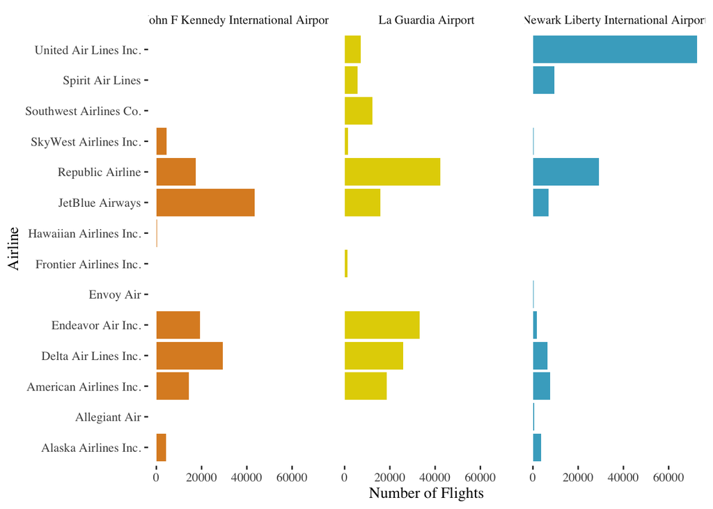

```r
flights |>
  left_join(airlines, by=join_by(carrier)) |> #join airline data
  rename(carrier_name=name) |> # change name to carrier_name
  left_join(airports, by=join_by(origin==faa)) |> # join airport data
  rename(airport_name=name) |> # change name to airport_name
  ggplot(aes(y=carrier_name, fill=airport_name)) +
  geom_bar() +
  scale_fill_manual(values=wes_palette("FantasticFox1")) +
  labs(fill="Departure\nAirport",
       y="Airline",
       x="Number of Flights") +
  facet_wrap(~ airport_name) +
  theme_tufte() +
  theme(legend.position = "none") # suppress legend entirely
```

Exploring relationships between variables in separate tables:

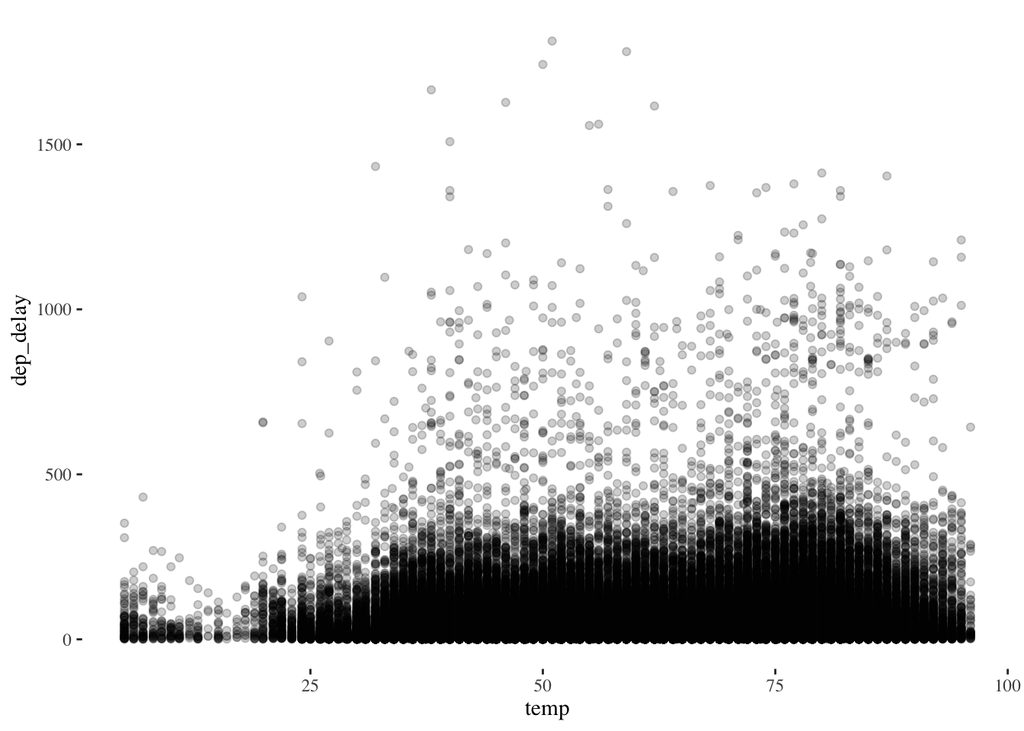

```r
library(viridis)

# look at the relationship between temp and dep_delay in the flights and weather joined dataset (filter for dep_delay > 0)

flights_weather_inner_join |>
  filter(dep_delay > 0) |>
  ggplot(aes(x=temp, y=dep_delay)) +
  geom_point(alpha=0.2) +
  theme_tufte()
```

To bet a better look at data density in this plot, we can view it using `geom_hex()` which shows the number of points that fall within each hexagon. This allows us to see the regions where we have tons of points plotting on top of each other.

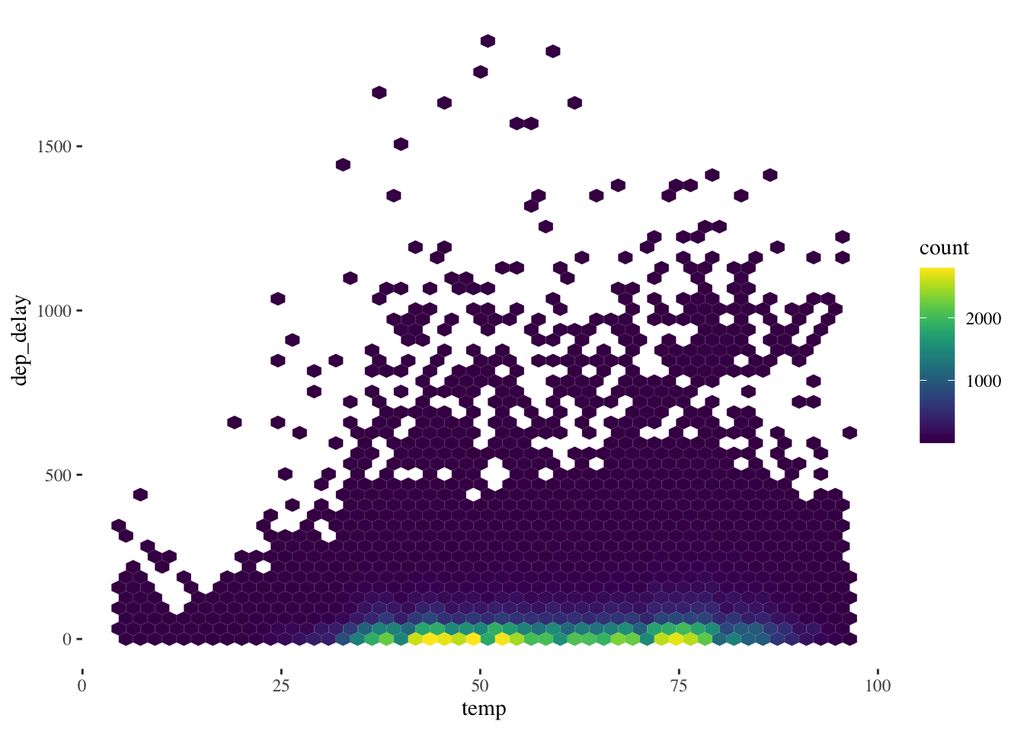

```r
flights_weather_inner_join |>
  filter(dep_delay > 0) |>
  ggplot(aes(x=temp, y=dep_delay)) +
  geom_hex(bins=50) +
  scale_fill_viridis() +
  theme_tufte()
```

Let’s go back to the scatter plot and add another variable by color.

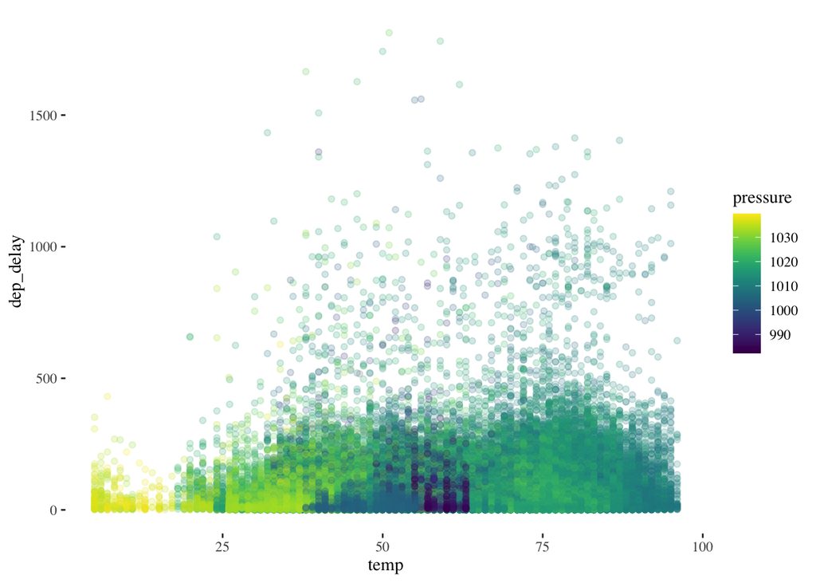

```r
# add color by another variable

flights_weather_inner_join |>
  filter(dep_delay > 0) |>
  ggplot(aes(x=temp, y=dep_delay, color=pressure)) +
  geom_point(alpha=0.2) +
  scale_color_viridis() +
  theme_tufte()
```